# Daghestanian loans database

## Introduction

This try-out database contains wordlists collected as part of the [Daghestanian loans](https://ilcl.hse.ru/en/projects) project by the [Linguistic Convergence Laboratory](https://ilcl.hse.ru/en/) at NRU HSE. The aim of the 160-item shortlist, which is based on the [World Loanword Database questionnaire](https://wold.clld.org/), is to measure lexical contact on a micro-level. In other words, to quantify lexical convergence among the speech communities of minority languages on a village-level, and to detect fine-grained areal patterns beyond general observations on the spheres of influence of certain languages.

## The Database

|  | Concept number | Source concept | WOLD core list | LWT code | Stem number | Language | Village | Region | Respondent | Supposed toplevel source | Comment |
| --- | --- | --- | --- | --- | --- | --- | --- | --- | --- | --- | --- |
| 1376 NA | 1 | the ant | Yes | 3.817 | 1.5 | Lezgian | Arkhit | Khiv | Arkhit1 |  |  |
| 1288 NA | 2 | the arch | Yes | 7.58 | 2.5 | Lezgian | Arkhit | Khiv | Arkhit1 |  |  |
| 1437 NA | 3 | the axe/ax | Yes | 9.25 | 3.6 | Lezgian | Arkhit | Khiv | Arkhit1 |  |  |
| 1378 tup | 4 | the ball | Yes | 12.83 | 4.3 | Lezgian | Arkhit | Khiv | Arkhit1 |  |  |
| 1292 NA | 5 | the barrel | No |  | 5.2 | Lezgian | Arkhit | Khiv | Arkhit1 |  |  |
| 1359 NA | 6 | the bat | Yes | 3.591 | 6.9 | Lezgian | Arkhit | Khiv | Arkhit1 |  |  |
| 1340 NA | 7 | the beak | Yes | 4.241 | 7.7 | Lezgian | Arkhit | Khiv | Arkhit1 |  |  |
| 1291 NA | 8 | the beard | Yes | 4.142 | 8.4 | Lezgian | Arkhit | Khiv | Arkhit1 |  |  |
| 1311 mum | 9 | the beeswax | Yes | 3.821 | 9.4 | Lezgian | Arkhit | Khiv | Arkhit1 |  |  |
| 1402 č’ul | 10 | the belt | Yes | 6.57 | 10.9 | Lezgian | Arkhit | Khiv | Arkhit1 |  |  |

[output cut: 3442 more lines]

Version: 2018-11-19. For questions or comments contact jh.verhees@gmail.com.

## Structure of the data

The table below shows the number of collected wordlists and the total number of lexical entries currently in the database.

```
##       [,1]
## lists   21
## total 3452
```

For each lexical entry the following parameters are given:

- Entry number - Unique entry number for each attested lexical item
- Target word - Transliteration of the attested word
- Target cyrillic - Attested word in Cyrillic orthography
- Concept number - Number of the source concept in the 160-list
- Source concept - Concept from the 160-list
- Russian stimulus - Russian translation of the source concepts used to elicit in the field
- WOLD core list - Indicates whether the source concept is part of the [WOLD](https://wold.clld.org/) core list
- LWT code - [WOLD](https://wold.clld.org/) code
- Stem number - Similar lexemes are grouped in similarity sets with the parameter stem number; similar lexemes are assigned the same stem number.
- Language
- Village
- Region - Administrative district
- Date (MM.YYYY) - Date when the material was collected; there is a separate file with metadata on speakers, villages and the researcher who recorded the list.
- Latitude / Longitude - Coordinates; in case of dictionary data, [Glottolog](https://glottolog.org/) coordinates are used.
- Respondent - Codename of the speaker; metadata contains information on gender and birthyear, but speakers remain anonymous.
- Full reference - This column contains source references of dictionaries
- Supposed toplevel source - The original source language of a lexeme (mediated borrowing is not taken into account)
- Suspected mediator - In case a path of mediated borrowing is known or more or less probable, it is indicated here
- Reference - Additional references on lexicon or the origin of a word are indicated here
- Comment - All kinds of additional comments
- Confirmed - In some cases, speakers were asked whether they knew a certain lexeme attested, for example, in a neighbouring village. These are indicated separately as “confirmed”.

Not all of these parameters are shown in the database above, but all the data is available on [Github](http://github.com/sverhees/loandatabase/).

### Map of the surveyed villages

The map below shows the villages surveyed and the number of lists collected in each village. Orange dots represent dictionary data. Hover over a dot to see the language it represents. When you click on a dot, a popup will appear that shows genetic info on the language, the name of the village or in case of the orange dots, the resource used.

[interactive chart not shown]

### The shortlist

Below is the shortlist of concepts and the Russian translation used to elicit in the field.

| Concept number | Source concept | Russian stimulus | WOLD core list | LWT code |
| --- | --- | --- | --- | --- |
| 1 | the ant | муравей | Yes | 3.817 |
| 2 | the arch | арка | Yes | 7.58 |
| 3 | the axe/ax | топор | Yes | 9.25 |
| 4 | the ball | мяч, шар | Yes | 12.83 |
| 5 | the barrel | бочка | No |  |
| 6 | the bat | летучая мышь | Yes | 3.591 |
| 7 | the beak | клюв | Yes | 4.241 |
| 8 | the beard | борода | Yes | 4.142 |
| 9 | the beeswax | воск (пчелиный) | Yes | 3.821 |
| 10 | the belt | ремень, пояс | Yes | 6.57 |

[output cut: 151 more lines]

### List length

While the list of concepts consists of 160 items, the collected lists rarely do. There can be two or more translations for a single concept, or speakers might not remember how to translate all of the concepts. Below is a density plot showing the dispersion of wordlist length.

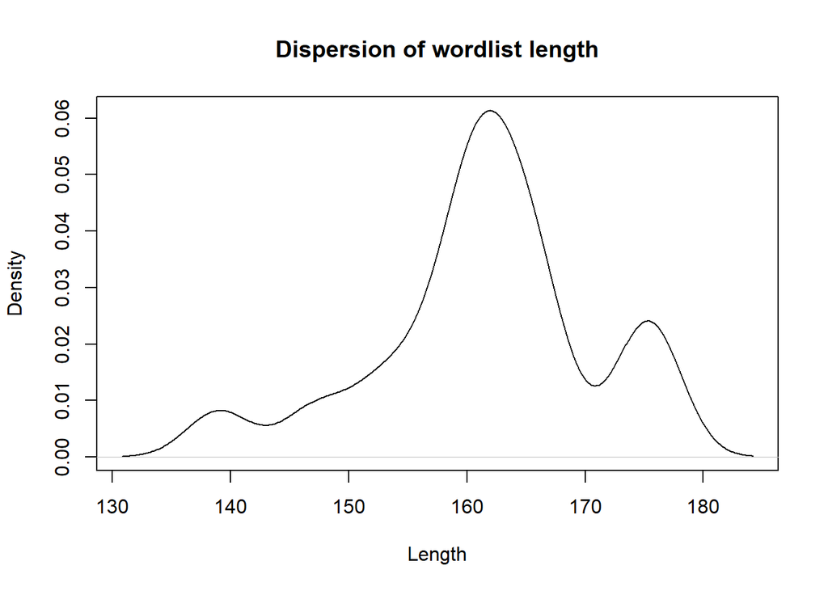

### Number of loans in the sample by donor language

The graph below shows the number of words for each source across the sample.

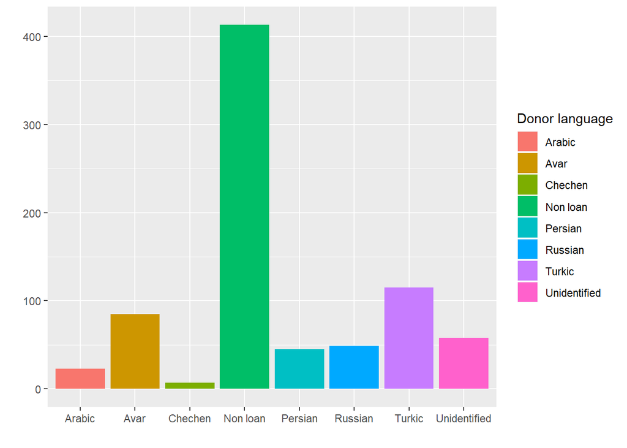

## Word maps

The database also contains coordinates. Village coordinates for villages, and Glottolog coordinates for dictionary data. These coordinates can be used to plot the distribution of a certain lexeme on the map. Below are some examples. (The maps on ‘pepper’ were made with a different datatset for this word, specifically.)

### Bucket

[interactive chart not shown]

### Butterfly

[interactive chart not shown]

### Pepper

The maps below show the spread of different words for ‘(black) pepper’ (*piper nigrum*) among languages spoken in the eastern part of the North Caucasus region, including East Caucasian / Nakh-Daghestanian languages and local varieties of Turkic. Most of the attested lexemes are borrowed (from Turkic to East Caucasian), and their distribution on the map reflects the areal influence of different L2s. The southern part of the area, for example, is dominated by Azerbaijani. In the north-central area, patterns of influence are more complicated: Avar is a major L2, but it has several words for ‘pepper’, which in turn were borrowed from other languages. Languages spoken in the same area could have borrowed these words from Avar, or from their original source (e.g. Kumyk or Nogai). In a few villages, the Russian word *perec* is commonly used.

### Total entries

| Type | n |
| --- | --- |
| 1. istiot | 69 |
| 2. burč | 25 |
| 3. pilpil | 16 |
| 4. perec | 6 |
| 5. žibži | 7 |
| 6. other | 12 |
| total | 135 |

### Data

The data are a combination of fieldwork, entries from the [IDS database](https://ids.clld.org/) and various dictionaries. Click on a dot to view:

- Language and genetic affiliation
- **Word:** form of the lexeme
- **Location:** coordinates of the datapoint and the associated location, which can be a certain village or a datapoint from the [Glottolog](https://glottolog.org/) database
- Type of resource used (e.g. a dictionary, or fieldwork)
- Reference to a specific source; in case of fieldwork, codenames are used.

Ideally, the table will be updated continuously with more precise information from specific villages. Full data is available [here](http://github.com/sverhees/loandatabase/). Contact jh.verhees@gmail.com for questions, comments, complaints or corrections.

#### Map 1. Distribution of *istiot* vs. other words

[interactive chart not shown]

#### Map 2. Different words for ‘pepper’

[interactive chart not shown]